# Projecting Trends in Female Technology Employment

Cameron Jester

2/23/2023

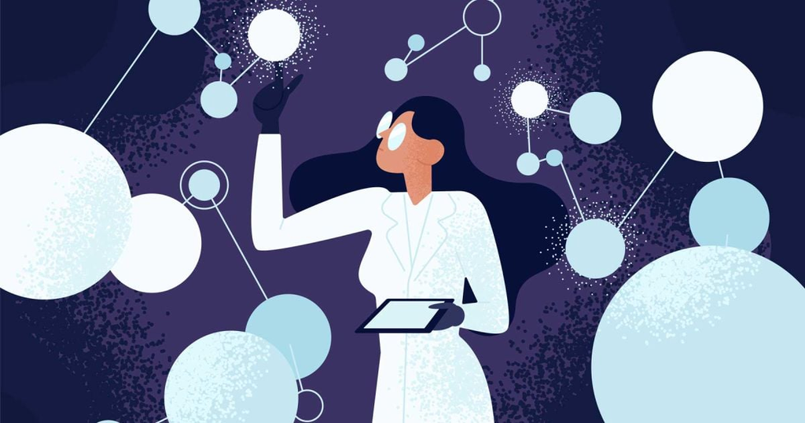

Image Courtesy of builtin.com

Hello All!

Thank you for taking the time to look at my most recent project: Projecting Trends in Female Technology Employment. I was inspired to create this project from material covered in my STAT 391: Time Series Analysis course, so much of my analysis/themes will stem from there. As a woman getting a degree in a technological field, I was particular interested in looking at data that will one day include me! I hope to gain insights into hiring trends to predict trends for when I enter the workforce and beyond. Additionally, I hope that this project will allow me to become more well-versed in some of the issues plaguing women in technology and use that information to make long-term change. Thanks again for looking through my project. I will continue to update this page as I work through my analysis.

Best, Cameron Jester

*A few comments to mention before conducting this analysis*:

- The data collected has been separated into men’s and women’s categories, this is in no way meant to dismiss trans women in this industry, it is simply how government agencies have separated the data.
- It is also understood that is it not required to have gotten a degree (technology related or not) to be able to work in the technology field. For the sake of drawing conclusions I am using data on women who have gotten computer science degrees in the United States.

## Exploratory Data Analysis

First, I am importing the datasets I have created from information found on the United States Bureau of Labor Statistics as well as the National Center for Education Statistics.

```r
library(tseries)
library(readr)
working_data <- read_csv("~/Desktop/working_data.csv")
library(readr)
degree_data <- read_csv("~/Desktop/Degree_data.csv")
```

# Tranforming data into a time series

```r
men_pct_ts =ts((working_data[,6]), start = c(2012,1), end = c(2022,12), frequency = 12)
wmn_pct_ts = ts((working_data[,5]), start = c(2012,1), end = c(2022,12), frequency = 12)
```

```r
bac_wmn = ts((degree_data[,4]), start = c(2011), end = c(2020,1), frequency = 1)
bac_men = ts((degree_data[,3]), start = c(2011), end = c(2020,1), frequency = 1)
bac_wmn_pct = ts((degree_data[,5]), start = c(2011), end = c(2020,1), frequency = 1)

masters_wmn = ts((degree_data[,8]), start = c(2011), end = c(2020,1), frequency = 1)
masters_men = ts((degree_data[,7]), start = c(2011), end = c(2020,1), frequency = 1)
masters_wmn_pct = ts((degree_data[,9]), start = c(2011), end = c(2020,1), frequency = 1)

doctorate_wmn = ts((degree_data[,13]), start = c(2011), end = c(2020,1), frequency = 1)
doctorate_men = ts((degree_data[,12]), start = c(2011), end = c(2020,1), frequency = 1)
doctorate_wmn_pct = ts((degree_data[,14]), start = c(2011), end = c(2020,1), frequency = 1)
```

Now I will plot the percentages of Bachelors, Masters, and Doctorate Computer Science degrees awarded to women.

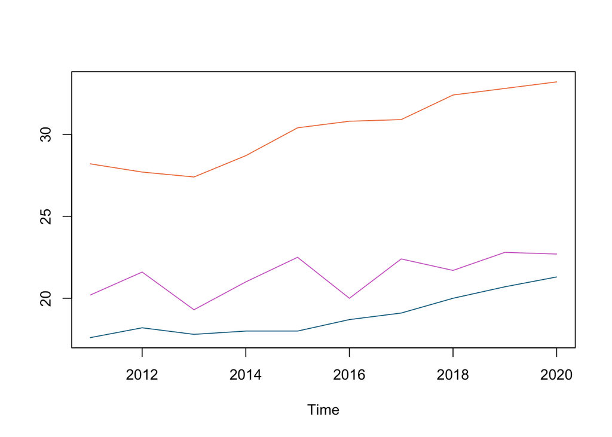

```r
ts.plot((cbind(bac_wmn_pct,masters_wmn_pct, doctorate_wmn_pct)), gpars = list(col = c("deepskyblue4", "sienna2", "orchid3")))
```

The plot above shows that Master’s programs (orange) has the highest percentage of degrees awarded to women, Bachelor’s programs (blue) have the lowest percentage of degrees awarded to women, and Doctorate programs (purple) are in the middle.

Let’s look into the montly data for women holding positions in technology.

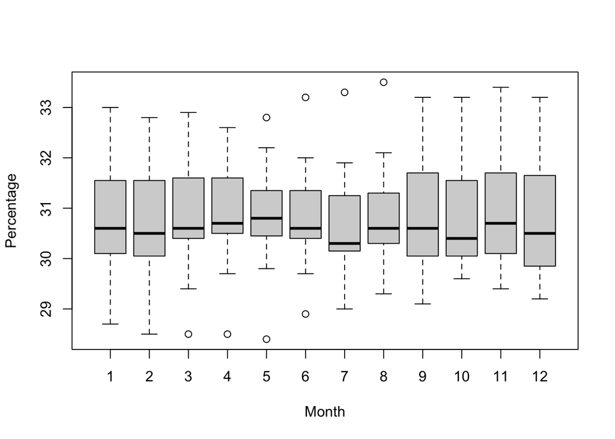

```r
boxplot(wmn_pct_ts~cycle(wmn_pct_ts), xlab = "Month", ylab = "Percentage")
```

We can see from the boxplot above that the mean stays consistent throughout the year. We do see outliers from the months March to August.

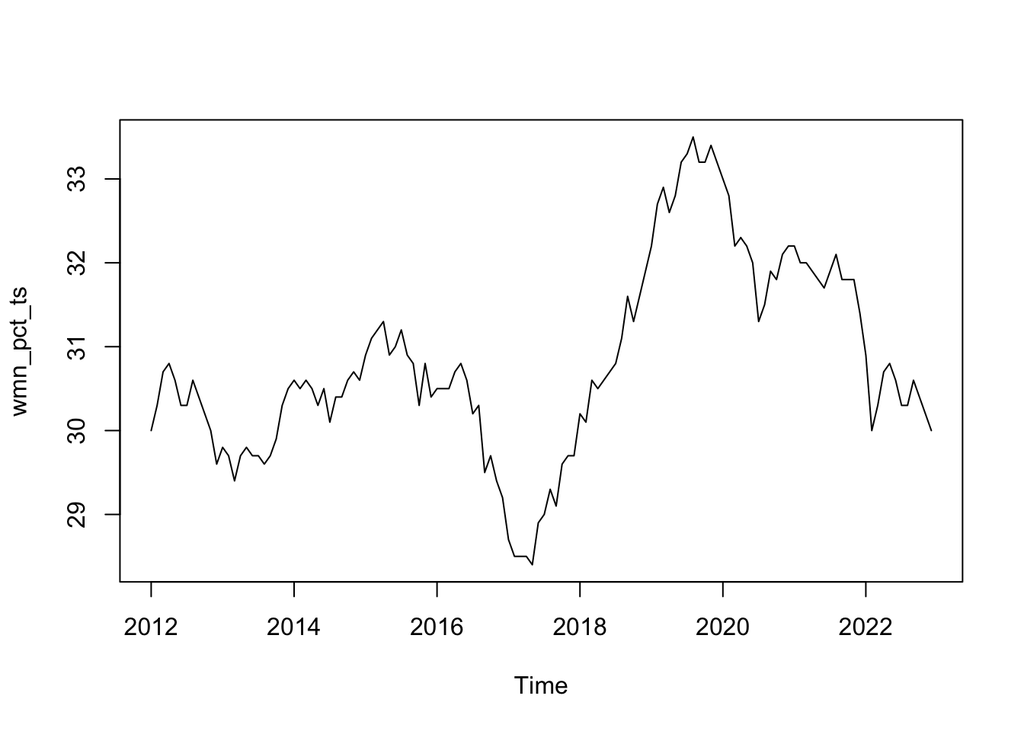

```r
plot(wmn_pct_ts)
```

Once I collect more data, I will be curious to see any trends in 2017 and 2019 that could account for the spikes we see in the graph above.

## Decomposing

As we have monthly data for the women working in technology dataset, it would be worthwhile to decompose the model to look for seasonal trends

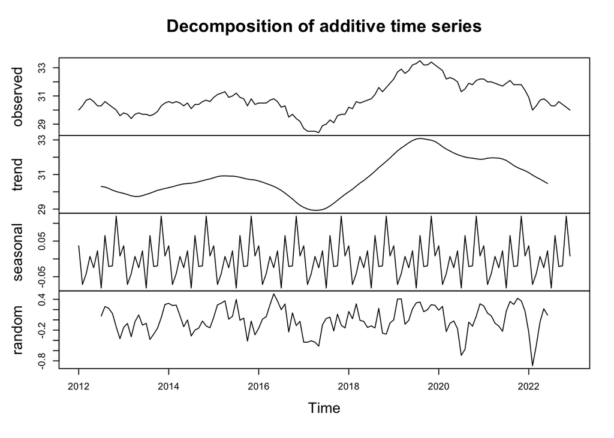

```r
wmnpct_decomp = decompose(wmn_pct_ts)

plot(wmnpct_decomp)
```

We can see from the decomposed plot that the mean is changing over time, which points to non-stationarity. It would be helpful here to conduct an ADF Test to obtain a p-value for our model.

```r
adf.test(wmn_pct_ts)
```

```
##
##  Augmented Dickey-Fuller Test
##
## data:  wmn_pct_ts
## Dickey-Fuller = -2.2999, Lag order = 5, p-value = 0.4518
## alternative hypothesis: stationary
```

The p-value here is 0.4518, which means we fail to reject the null at the Alpha Significance Level of 5%. With the ADF Test and the visual from the decomposed plot, I think it is safe to say the model is non-stationary.

# Differencing and Log Transformations

To help solve this case on non-stationarity, I am beginning to difference the model by using the diff function.

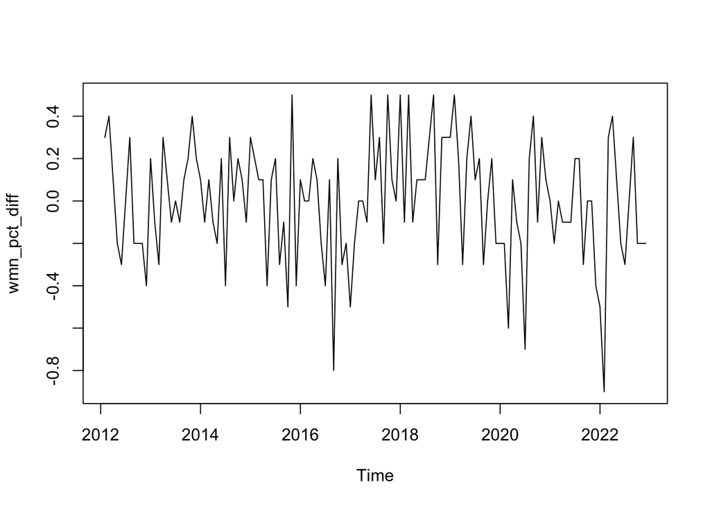

```r
wmn_pct_diff = diff(wmn_pct_ts)

plot(wmn_pct_diff)
```

By plotting this differenced model, we can see that the mean is now steady across time. The variance is not showing an issue here, therefore it would not be beneficial to continue to the log transformation steps to change the stationarity of this model. To be sure it would be good to check the ADF and ACF Tests.

```r
adf.test(wmn_pct_diff)
```

```
##
##  Augmented Dickey-Fuller Test
##
## data:  wmn_pct_diff
## Dickey-Fuller = -3.2049, Lag order = 5, p-value = 0.09018
## alternative hypothesis: stationary
```

The ADF Test here still gives us a p-value above the Alpha Significance Level, which would mean we fail to reject the null and that the data is non-stationary. One thing to note is that the p-value did decrease roughly .3 after creating a differenced model. It would be best to conduct an ACF Test as well.

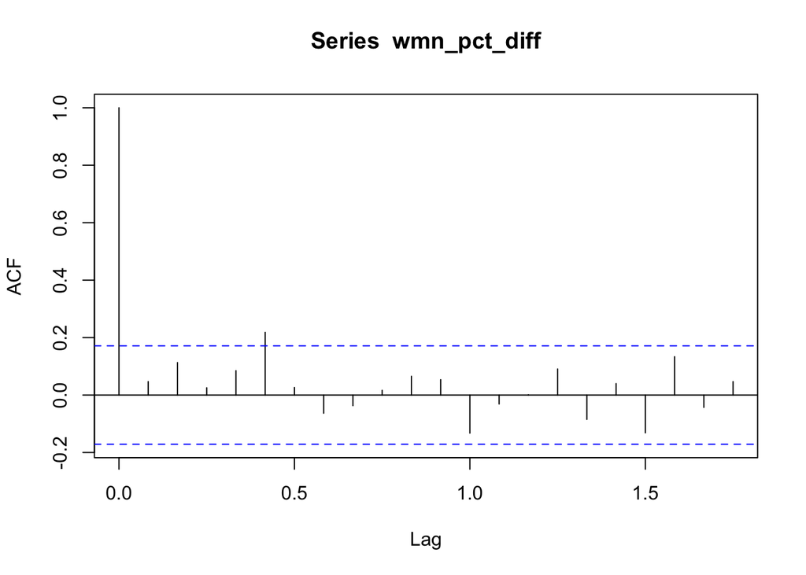

```r
acf(wmn_pct_diff)
```

## Next Steps:

Additionally, I would like to find qualitative data to supplement the models that I have created thus far. I would also like to look into past or future legislation that has/will make technology a more equitable field for women.

One technical note as well, I am still new to creating ts plots in R, so I am working my way around creating visuals and I intend to have better labels in the next update. Also, I plan on going into more in-depth explanation of my models in the future as well.

Thanks again, and I look forward to updating you all on my progress!